# Modern Data Mining - HW 5

Diego G. Dávila

Margaret Gardner

Joelle Bagautdinova

Due: 11:59Pm, 4/10, 2022

# Overview

For the purpose of predictions, a model free approach could be beneficial. A binary decision tree is the simplest, still interpretable and often provides insightful information between predictors and responses. To improve the predictive power we would like to aggregate many equations, especially uncorrelated ones. One clever way to have many free samples is to take bootstrap samples. For each bootstrap sample we build a random tree by taking a randomly chosen number of variables to be split at each node. We then take average of all the random bootstrap trees to have our final prediction equation. This is RandomForest.

Ensemble method can be applied broadly: simply take average or weighted average of many different equations. This may beat any single equation in your hand.

All the methods covered can handle both continuous responses as well as categorical response with multiple levels (not limited to binary response.)

## Objectives

- Understand trees
  - single tree/displaying/pruning a tree
  - RandomForest
  - Ensemble idea
- R functions/Packages
  - `tree`, `RandomForest`, `ranger`
- Json data format
- text mining
  - bag of words

Data needed:

- `IQ.Full.csv`
- `yelp_review_20k.json`

# Problem 0: Lectures

Please study all three lectures. Understand the main elements in each lecture and be able to run and compile the lectures

- textmining
- trees
- boosting

# Problem 1: IQ and successes

## Background: Measurement of Intelligence

Case Study: how intelligence relates to one’s future successes?

**Data needed: `IQ.Full.csv`**

ASVAB (Armed Services Vocational Aptitude Battery) tests have been used as a screening test for those who want to join the army or other jobs.

Our data set IQ.csv is a subset of individuals from the 1979 National Longitudinal Study of Youth (NLSY79) survey who were re-interviewed in 2006. Information about family, personal demographic such as gender, race and education level, plus a set of ASVAB (Armed Services Vocational Aptitude Battery) test scores are available. It is STILL used as a screening test for those who want to join the army! ASVAB scores were 1981 and income was 2005.

**Our goals:**

- Is IQ related to one’s successes measured by Income?
- Is there evidence to show that Females are under-paid?
- What are the best possible prediction models to predict future income?

**The ASVAB has the following components:**

- Science, Arith (Arithmetic reasoning), Word (Word knowledge), Parag (Paragraph comprehension), Numer (Numerical operation), Coding (Coding speed), Auto (Automative and Shop information), Math (Math knowledge), Mechanic (Mechanic Comprehension) and Elec (Electronic information).
- AFQT (Armed Forces Qualifying Test) is a combination of Word, Parag, Math and Arith.
- Note: Service Branch requirement: Army 31, Navy 35, Marines 31, Air Force 36, and Coast Guard 45,(out of 100 which is the max!)

**The detailed variable definitions:**

Personal Demographic Variables:

- Race: 1 = Hispanic, 2 = Black, 3 = Not Hispanic or Black
- Gender: a factor with levels “female” and “male”
- Educ: years of education completed by 2006

Household Environment:

- Imagazine: a variable taking on the value 1 if anyone in the respondent’s household regularly read magazines in 1979, otherwise 0
- Inewspaper: a variable taking on the value 1 if anyone in the respondent’s household regularly read newspapers in 1979, otherwise 0
- Ilibrary: a variable taking on the value 1 if anyone in the respondent’s household had a library card in 1979, otherwise 0
- MotherEd: mother’s years of education
- FatherEd: father’s years of education

Variables Related to ASVAB test Scores in 1981 (Proxy of IQ’s)

- AFQT: percentile score on the AFQT intelligence test in 1981
- Coding: score on the Coding Speed test in 1981
- Auto: score on the Automotive and Shop test in 1981
- Mechanic: score on the Mechanic test in 1981
- Elec: score on the Electronics Information test in 1981
- Science: score on the General Science test in 1981
- Math: score on the Math test in 1981
- Arith: score on the Arithmetic Reasoning test in 1981
- Word: score on the Word Knowledge Test in 1981
- Parag: score on the Paragraph Comprehension test in 1981
- Numer: score on the Numerical Operations test in 1981

Variable Related to Life Success in 2006

- Income2005: total annual income from wages and salary in 2005. We will use a natural log transformation over the income.

**Note: All the Esteem scores shouldn’t be used as predictors to predict income**

## 1. EDA: Some cleaning work is needed to organize the data.

- The first variable is the label for each person. Take that out.
- Set categorical variables as factors.
- Make log transformation for Income and take the original Income out
- Take the last person out of the dataset and label it as **Michelle**.
- When needed, split data to three portions: training, testing and validation (70%/20%/10%)
  - training data: get a fit
  - testing data: find the best tuning parameters/best models
  - validation data: only used in your final model to report the accuracy.

Data summary

| Name | df |
| --- | --- |
| Number of rows | 2583 |
| Number of columns | 21 |
| _______________________ |  |
| Column type frequency: |  |
| factor | 5 |
| numeric | 16 |
| ________________________ |  |
| Group variables | None |

**Variable type: factor**

| skim_variable | n_missing | complete_rate | ordered | n_unique | top_counts |
| --- | --- | --- | --- | --- | --- |
| Imagazine | 0 | 1 | FALSE | 2 | 1: 1843, 0: 740 |
| Inewspaper | 0 | 1 | FALSE | 2 | 1: 2225, 0: 358 |
| Ilibrary | 0 | 1 | FALSE | 2 | 1: 1993, 0: 590 |
| Race | 0 | 1 | FALSE | 3 | 3: 2181, 2: 237, 1: 165 |
| Gender | 0 | 1 | FALSE | 2 | mal: 1306, fem: 1277 |

**Variable type: numeric**

| skim_variable | n_missing | complete_rate | mean | sd | p0 | p25 | p50 | p75 | p100 | hist |
| --- | --- | --- | --- | --- | --- | --- | --- | --- | --- | --- |
| MotherEd | 0 | 1 | 11.70 | 2.62 | 0.00 | 11.00 | 12.00 | 12.00 | 20.00 | ▁▁▇▂▁ |
| FatherEd | 0 | 1 | 11.85 | 3.55 | 0.00 | 10.00 | 12.00 | 14.00 | 20.00 | ▁▂▇▃▁ |
| FamilyIncome78 | 0 | 1 | 21099.24 | 13857.32 | 0.00 | 11000.00 | 20000.00 | 27050.00 | 75001.00 | ▇▇▂▁▁ |
| Educ | 0 | 1 | 13.89 | 2.50 | 6.00 | 12.00 | 13.00 | 16.00 | 20.00 | ▁▁▇▃▂ |
| Science | 0 | 1 | 16.25 | 4.77 | 0.00 | 13.00 | 17.00 | 20.00 | 25.00 | ▁▂▆▇▅ |
| Arith | 0 | 1 | 18.52 | 7.16 | 0.00 | 13.00 | 19.00 | 25.00 | 30.00 | ▁▆▇▇▇ |
| Word | 0 | 1 | 26.56 | 7.05 | 0.00 | 23.00 | 28.00 | 32.00 | 35.00 | ▁▁▂▅▇ |
| Parag | 0 | 1 | 11.20 | 3.16 | 0.00 | 10.00 | 12.00 | 14.00 | 15.00 | ▁▂▂▆▇ |
| Numer | 0 | 1 | 35.33 | 10.20 | 0.00 | 28.00 | 36.00 | 44.00 | 50.00 | ▁▂▅▇▇ |
| Coding | 0 | 1 | 46.88 | 15.28 | 0.00 | 38.00 | 48.00 | 57.00 | 84.00 | ▁▃▇▇▂ |
| Auto | 0 | 1 | 14.24 | 5.30 | 0.00 | 10.00 | 14.00 | 18.00 | 25.00 | ▁▆▇▆▃ |
| Math | 0 | 1 | 14.20 | 6.28 | 0.00 | 9.00 | 13.00 | 20.00 | 25.00 | ▂▇▇▆▆ |
| Mechanic | 0 | 1 | 14.38 | 5.09 | 0.00 | 11.00 | 14.00 | 18.00 | 25.00 | ▁▅▇▆▃ |
| Elec | 0 | 1 | 11.58 | 4.09 | 0.00 | 9.00 | 12.00 | 15.00 | 20.00 | ▁▅▇▇▃ |
| AFQT | 0 | 1 | 54.45 | 27.76 | 0.00 | 31.49 | 56.81 | 78.08 | 100.00 | ▅▆▇▇▇ |
| log_income | 0 | 1 | 10.44 | 0.97 | 4.14 | 10.04 | 10.55 | 11.02 | 13.46 | ▁▁▂▇▁ |

## 2. Factors affect Income

We only use linear models to answer the questions below.

1. To summarize ASVAB test scores, create PC1 and PC2 of 10 scores of ASVAB tests and label them as ASVAB_PC1 and ASVAB_PC2. Give a quick interpretation of each ASVAB_PC1 and ASVAB_PC2 in terms of the original 10 tests.

```
##                PC1         PC2         PC3        PC4          PC5         PC6
## Science  0.3518528 -0.14181863  0.21948841 -0.1636305  0.030591564 -0.42854688
## Arith    0.3543093  0.04873546  0.09873843  0.4750484  0.057688063  0.06276129
## Word     0.3496059  0.06147760  0.33817070 -0.3802031  0.005898209 -0.13123863
## Parag    0.3262639  0.18966524  0.38608569 -0.3573093 -0.043828700  0.60948713
## Numer    0.2748967  0.45177204 -0.32698673  0.0807212 -0.743725969 -0.01372396
## Coding   0.2338653  0.51465945 -0.51819879 -0.2382979  0.576194992 -0.11369751
## Auto     0.2722293 -0.47336402 -0.42498125 -0.1515028 -0.183148886  0.09999147
## Math     0.3359736  0.14256444  0.23044656  0.5747080  0.138836906 -0.15848263
## Mechanic 0.3160660 -0.33469628 -0.24844011  0.2020363  0.229262622  0.48491508
## Elec     0.3237995 -0.33521321 -0.08812776 -0.1340407 -0.057192332 -0.37461621
##                   PC7         PC8          PC9        PC10
## Science  -0.483126035  0.23064005 -0.460462696  0.31291731
## Arith     0.050841551 -0.29915443  0.323291466  0.65788067
## Word     -0.173657463  0.06370937  0.704043519 -0.26063574
## Parag     0.222208531 -0.16717978 -0.358611400  0.03903163
## Numer    -0.037281110  0.22790114 -0.006766001 -0.01436462
## Coding    0.021429893 -0.08395546 -0.043721008  0.02774368
## Auto     -0.271365016 -0.59351090 -0.026652279 -0.16765816
## Math      0.002376798 -0.16143946 -0.218801283 -0.60420811
## Mechanic -0.101376933  0.61275990  0.081371178 -0.07390737
## Elec      0.773756939  0.11190978 -0.044882091  0.01436274
```

**Interpretation:**

- ASVAB_PC1 appears to be a weighted sum of all 10 items and can thus be interpreted as a general ASVAB score.
- ASVAB_PC2 appears to capture the difference between performance in more abstract reasoning (Arith, Word, Parag, Numer, Coding, Math) vs more applied tasks (Science, Auto, Mechanic, Elec).
2. Is there any evidence showing ASVAB test scores in terms of ASVAB_PC1 and ASVAB_PC2, might affect the Income? Show your work here. You may control a few other variables, including gender.

```
##
## Call:
## lm(formula = log_income ~ ASVAB_PC1 + ASVAB_PC2, data = df)
##
## Residuals:
##     Min      1Q  Median      3Q     Max
## -6.5996 -0.3667  0.1338  0.5347  2.7197
##
## Coefficients:
##              Estimate Std. Error t value Pr(>|t|)
## (Intercept) 10.437589   0.017982 580.441  < 2e-16 ***
## ASVAB_PC1    0.131772   0.007276  18.111  < 2e-16 ***
## ASVAB_PC2   -0.075312   0.015078  -4.995 6.28e-07 ***
## ---
## Signif. codes:  0 '***' 0.001 '**' 0.01 '*' 0.05 '.' 0.1 ' ' 1
##
## Residual standard error: 0.9139 on 2580 degrees of freedom
## Multiple R-squared:  0.1203, Adjusted R-squared:  0.1197
## F-statistic: 176.5 on 2 and 2580 DF,  p-value: < 2.2e-16
```

```
##
## Call:
## lm(formula = log_income ~ ASVAB_PC1 + ASVAB_PC2 + Gender, data = df)
##
## Residuals:
##     Min      1Q  Median      3Q     Max
## -6.7273 -0.3462  0.1245  0.5244  2.6121
##
## Coefficients:
##              Estimate Std. Error t value Pr(>|t|)
## (Intercept) 10.098144   0.028181 358.336  < 2e-16 ***
## ASVAB_PC1    0.109464   0.007123  15.367  < 2e-16 ***
## ASVAB_PC2    0.094176   0.018239   5.163 2.61e-07 ***
## Gendermale   0.671353   0.044107  15.221  < 2e-16 ***
## ---
## Signif. codes:  0 '***' 0.001 '**' 0.01 '*' 0.05 '.' 0.1 ' ' 1
##
## Residual standard error: 0.8756 on 2579 degrees of freedom
## Multiple R-squared:  0.1928, Adjusted R-squared:  0.1919
## F-statistic: 205.4 on 3 and 2579 DF,  p-value: < 2.2e-16
```

```
## Anova Table (Type II tests)
##
## Response: log_income
##            Sum Sq   Df  F value    Pr(>F)
## ASVAB_PC1  160.84    1 209.7614 < 2.2e-16 ***
## ASVAB_PC2   19.46    1  25.3770 5.041e-07 ***
## Gender     173.72    1 226.5609 < 2.2e-16 ***
## Race         1.27    2   0.8298    0.4362
## Residuals 1976.00 2577
## ---
## Signif. codes:  0 '***' 0.001 '**' 0.01 '*' 0.05 '.' 0.1 ' ' 1
```

```
##
## Call:
## lm(formula = log_income ~ ASVAB_PC1 + ASVAB_PC2 + Gender + Educ,
##     data = df)
##
## Residuals:
##     Min      1Q  Median      3Q     Max
## -7.0615 -0.3240  0.1416  0.5032  2.5412
##
## Coefficients:
##             Estimate Std. Error t value Pr(>|t|)
## (Intercept) 9.080127   0.118414  76.681  < 2e-16 ***
## ASVAB_PC1   0.069476   0.008349   8.321  < 2e-16 ***
## ASVAB_PC2   0.063019   0.018314   3.441 0.000589 ***
## Gendermale  0.670640   0.043461  15.431  < 2e-16 ***
## Educ        0.073311   0.008290   8.844  < 2e-16 ***
## ---
## Signif. codes:  0 '***' 0.001 '**' 0.01 '*' 0.05 '.' 0.1 ' ' 1
##
## Residual standard error: 0.8628 on 2578 degrees of freedom
## Multiple R-squared:  0.2166, Adjusted R-squared:  0.2154
## F-statistic: 178.2 on 4 and 2578 DF,  p-value: < 2.2e-16
```

```
##
## Call:
## lm(formula = log_income ~ ASVAB_PC1 + ASVAB_PC2 + Gender + Educ +
##     MotherEd + FatherEd, data = df)
##
## Residuals:
##     Min      1Q  Median      3Q     Max
## -7.0259 -0.3249  0.1403  0.5049  2.5613
##
## Coefficients:
##              Estimate Std. Error t value Pr(>|t|)
## (Intercept)  9.083343   0.132359  68.626  < 2e-16 ***
## ASVAB_PC1    0.068286   0.008790   7.769 1.14e-14 ***
## ASVAB_PC2    0.062184   0.018331   3.392 0.000704 ***
## Gendermale   0.668942   0.043494  15.380  < 2e-16 ***
## Educ         0.072634   0.008618   8.428  < 2e-16 ***
## MotherEd    -0.007236   0.008545  -0.847 0.397177
## FatherEd     0.007739   0.006314   1.226 0.220401
## ---
## Signif. codes:  0 '***' 0.001 '**' 0.01 '*' 0.05 '.' 0.1 ' ' 1
##
## Residual standard error: 0.8629 on 2576 degrees of freedom
## Multiple R-squared:  0.2171, Adjusted R-squared:  0.2153
## F-statistic: 119.1 on 6 and 2576 DF,  p-value: < 2.2e-16
```

**Answer:** Based on the linear models above, the following observations can be made:

```
## Anova Table (Type II tests)
##
## Response: log_income
##            Sum Sq   Df F value    Pr(>F)
## ASVAB_PC1  181.05    1  236.14 < 2.2e-16 ***
## ASVAB_PC2   20.44    1   26.66 2.612e-07 ***
## Gender     177.63    1  231.68 < 2.2e-16 ***
## Residuals 1977.28 2579
## ---
## Signif. codes:  0 '***' 0.001 '**' 0.01 '*' 0.05 '.' 0.1 ' ' 1
```

```
##
## Call:
## lm(formula = log_income ~ ASVAB_PC1 + ASVAB_PC2 + Gender, data = df)
##
## Residuals:
##     Min      1Q  Median      3Q     Max
## -6.7273 -0.3462  0.1245  0.5244  2.6121
##
## Coefficients:
##              Estimate Std. Error t value Pr(>|t|)
## (Intercept) 10.098144   0.028181 358.336  < 2e-16 ***
## ASVAB_PC1    0.109464   0.007123  15.367  < 2e-16 ***
## ASVAB_PC2    0.094176   0.018239   5.163 2.61e-07 ***
## Gendermale   0.671353   0.044107  15.221  < 2e-16 ***
## ---
## Signif. codes:  0 '***' 0.001 '**' 0.01 '*' 0.05 '.' 0.1 ' ' 1
##
## Residual standard error: 0.8756 on 2579 degrees of freedom
## Multiple R-squared:  0.1928, Adjusted R-squared:  0.1919
## F-statistic: 205.4 on 3 and 2579 DF,  p-value: < 2.2e-16
```

```
## Analysis of Variance Table
##
## Model 1: log_income ~ ASVAB_PC1 + ASVAB_PC2
## Model 2: log_income ~ ASVAB_PC1 + ASVAB_PC2 + Gender
##   Res.Df    RSS Df Sum of Sq      F    Pr(>F)
## 1   2580 2154.9
## 2   2579 1977.3  1    177.63 231.68 < 2.2e-16 ***
## ---
## Signif. codes:  0 '***' 0.001 '**' 0.01 '*' 0.05 '.' 0.1 ' ' 1
```

We next build a few models for the purpose of prediction using all the information available. From now on you may use the three data sets setting (training/testing/validation) when it is appropriate.

## 3. Trees

1. fit1: tree(Income ~ Educ + Gender, data.train) with default set up
   1. Display the tree

```
##
## Regression tree:
## tree(formula = log_income ~ Educ + Gender, data = data.train)
## Number of terminal nodes:  4
## Residual mean deviance:  0.8214 = 1482 / 1804
## Distribution of residuals:
##    Min. 1st Qu.  Median    Mean 3rd Qu.    Max.
## -7.0260 -0.3509  0.1461  0.0000  0.5505  2.3930
```

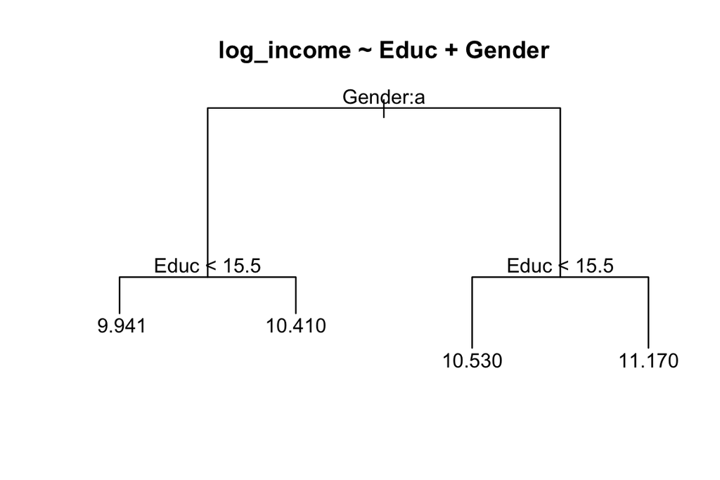

```
b) How many end nodes? Briefly explain how the estimation is obtained in each end nodes and describe the prediction equation
```

**Answer:** The tree has 4 end nodes, meaning that Gender and Education are partitioned into 4 boxes. The end node estimations correspond to the sample mean log_income for every end node. The prediction equation for this model is as follows:

- If gender == Female and years of education less than 15.5, the average log_income is 9.941
- If gender == Female and years of education more than 15.5, the average log_income is 10.410
- If gender == Male and years of education less than 15.5, the average log_income is 10.530
- If gender == Male and years of education more than 15.5, the average log_income is 11.170
  3. Does it show interaction effect of Gender and Educ over Income?

**Answer:** Yes, the tree shows an interaction between gender and income, where being male with more than 15.5 years of education corresponds to the highest log_income, and conversely being female with less than 15.5 years of education is associated with the lowest log_income.

```
d) Predict Michelle's income
```

```
##        fitted log_income
## 2584 9.940797   10.71442
```

**Answer:** Michelle’s predicted log_income is 9.941, which corresponds to $ 2.0760278^{4}.

2. fit2: fit2 <- rpart(Income2005 ~., data.train, minsplit=20, cp=.009)
   1. Display the tree using plot(as.party(fit2), main=“Final Tree with Rpart”)

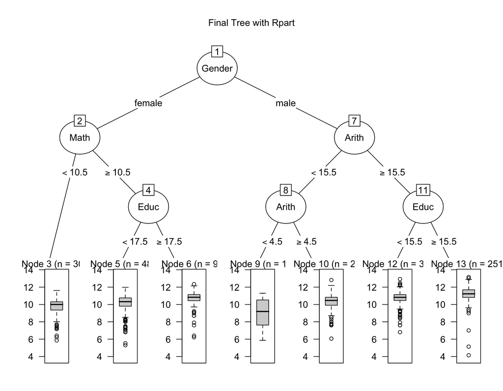

```
b) A brief summary of the fit2
```

```
c) Compare testing errors between fit1 and fit2. Is the training error from fit2 always less than that from fit1? Is the testing error from fit2 always smaller than that from fit1?
```

**Answer:** The training error of fit2 (1406.6899864) is smaller than the training error of fit1 (1481.7164089). However, the testing error of fit2 (346.1674643) is slightly larger than the testing error of fit1 (345.3060021). While the training error always should be smaller for trees that include more variables, this does not necessarily hold true for the testing error, as this corresponds to the model fit on unseen data.

```
d) You may prune the fit2 to get a tree with small testing error.
```

```
##
## Regression tree:
## rpart(formula = log_income ~ ., data = data.train, minsplit = 20,
##     cp = 0.009)
##
## Variables actually used in tree construction:
## [1] Arith  Educ   Gender Math
##
## Root node error: 1786/1808 = 0.98786
##
## n= 1808
##
##          CP nsplit rel error  xerror     xstd
## 1 0.1042909      0   1.00000 1.00092 0.056846
## 2 0.0464310      1   0.89571 0.89778 0.055256
## 3 0.0234418      2   0.84928 0.87000 0.056049
## 4 0.0165392      3   0.82584 0.84382 0.056035
## 5 0.0124641      4   0.80930 0.84628 0.056819
## 6 0.0092343      5   0.79683 0.83190 0.056706
## 7 0.0090000      6   0.78760 0.83062 0.056920
```

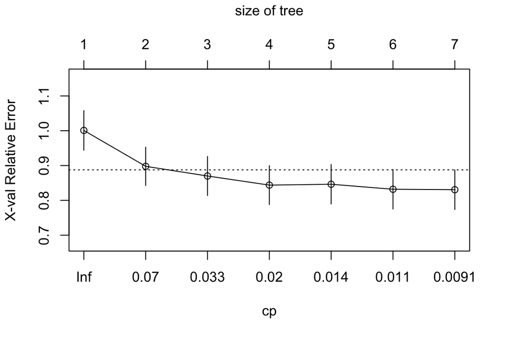

```
## [1] 0.009
```

```
## [1] "cp = 0.07:  381.446"
```

```
## [1] "cp = 0.033:  370.16"
```

```
## [1] "cp = 0.02:  353.81"
```

```
## [1] "cp = 0.014:  346.248"
```

```
## [1] "cp = 0.011:  344.947"
```

```
## [1] "cp = 0.0091:  346.167"
```

**Answer:** As it turns out, while cp = 0.009 has the smallest training error, cp = 0.011 has the smallest testing error. Thus, let’s build the pruned tree using this criterion:

```
##        var    n   wt        dev      yval  complexity ncompete nsurrogate
##  1: Gender 1808 1808 1786.04931 10.404886 0.104290926        4          5
##  2:   Math  881  881  825.41753 10.075638 0.023441829        4          5
##  3: <leaf>  306  306  242.04639  9.776806 0.005992624        0          0
##  4: <leaf>  575  575  541.50287 10.234669 0.009234310        0          0
##  5:  Arith  927  927  774.36305 10.717796 0.046430974        4          5
##  6:  Arith  304  304  248.16004 10.289624 0.012464106        4          1
##  7: <leaf>   11   11   35.59419  8.893005 0.009000000        0          0
##  8: <leaf>  293  293  190.30434 10.342057 0.005571635        0          0
##  9:   Educ  623  623  443.27500 10.926727 0.016539228        4          5
## 10: <leaf>  372  372  190.20291 10.747862 0.002533926        0          0
## 11: <leaf>  251  251  223.53221 11.191818 0.006437185        0          0
```

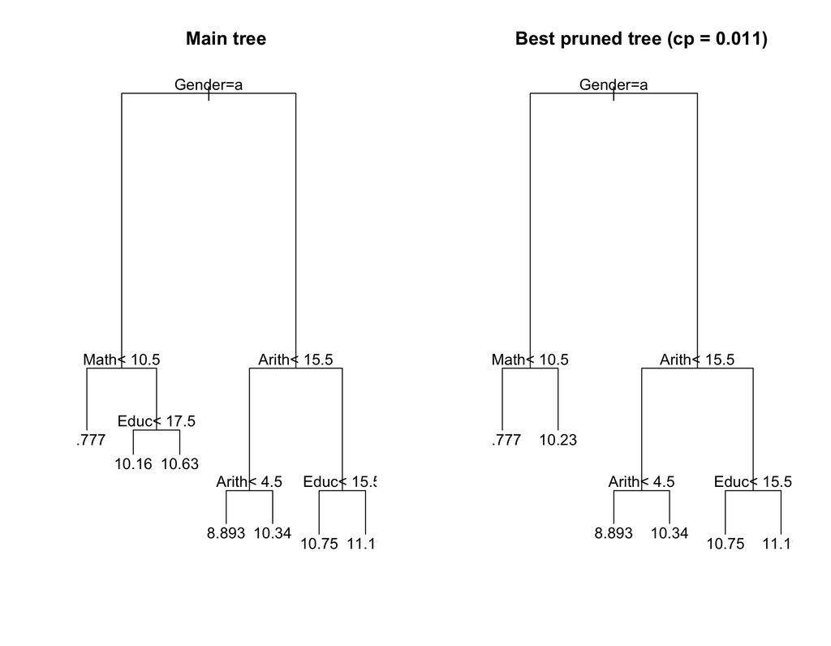

3. fit3: bag two trees

```
a) Take 2 bootstrap training samples and build two trees using the
rpart(Income2005 ~., data.train.b, minsplit=20, cp=.009). Display both trees.
```

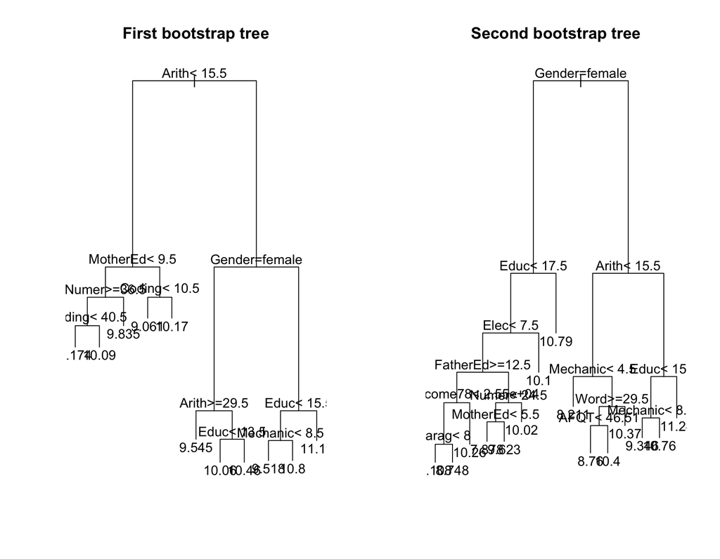

```
b) Explain how to get fitted values for Michelle by bagging the two trees obtained above. Do not use the predict().
```

```
##      Imagazine Inewspaper Ilibrary MotherEd FatherEd FamilyIncome78 Race Gender
## 2584         0          1        1        9        5          12410    3 female
##      Educ Science Arith Word Parag Numer Coding Auto Math Mechanic Elec   AFQT
## 2584   13      16     9   27    13    24     27   10   10        4    9 31.207
##      log_income
## 2584   10.71442
```

**Answer:** Michelle’s fitted values can be obtained without the predict() function by manually going through each tree node according to Michelle’s data. To obtain the fitted values of the two bagged trees, we than compute the average of the fitted values corresponding to Michelle’s category. Thus:

- Manually find the boot.1 fitted value for Michelle:
  - Arith is 9 < 15.5
  - MotherEd is 9 < 9.5
  - Numer is 24 < 36.5
  - Coding is 27 < 40.5

```
## [1] "fit3 testing error:  1.064"
```

**Answer:** While generally bagging two trees will very likely tend to reduce the testing error, this does not necessarily hold rue when bbagging just two trees. More specifically, if one of the trees happen to have a large testing error, the resulting bagged testing error will be afffected and may be larger than the testing error of the “better” other input tree.

4. fit4: Build a best possible RandomForest
   1. Show the process how you tune mtry and number of trees. Give a very high level explanation how fit4 is built.

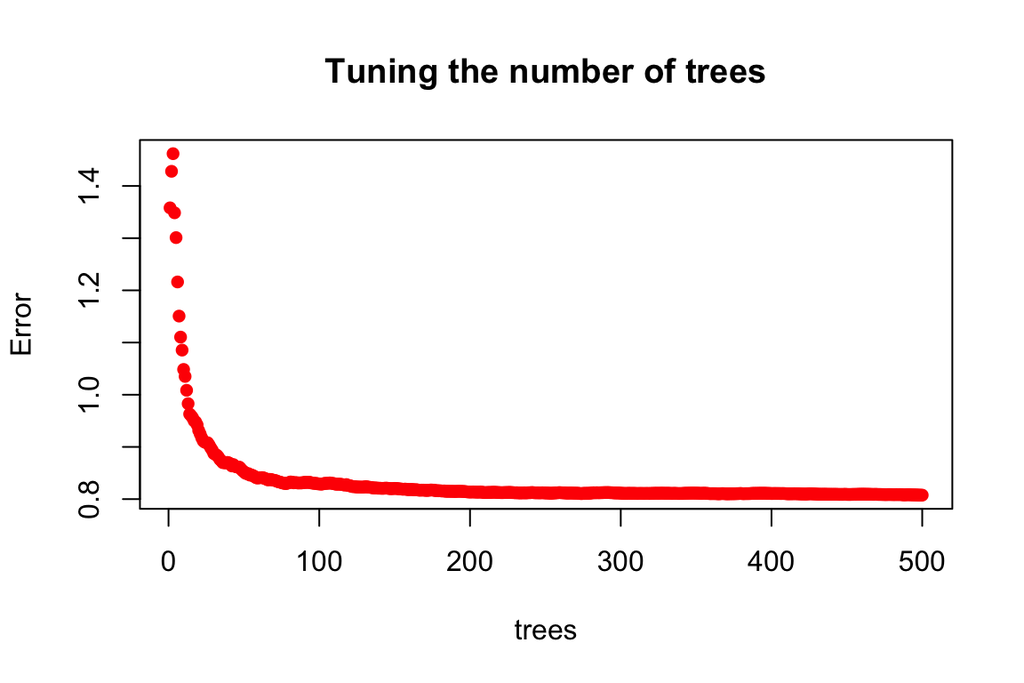

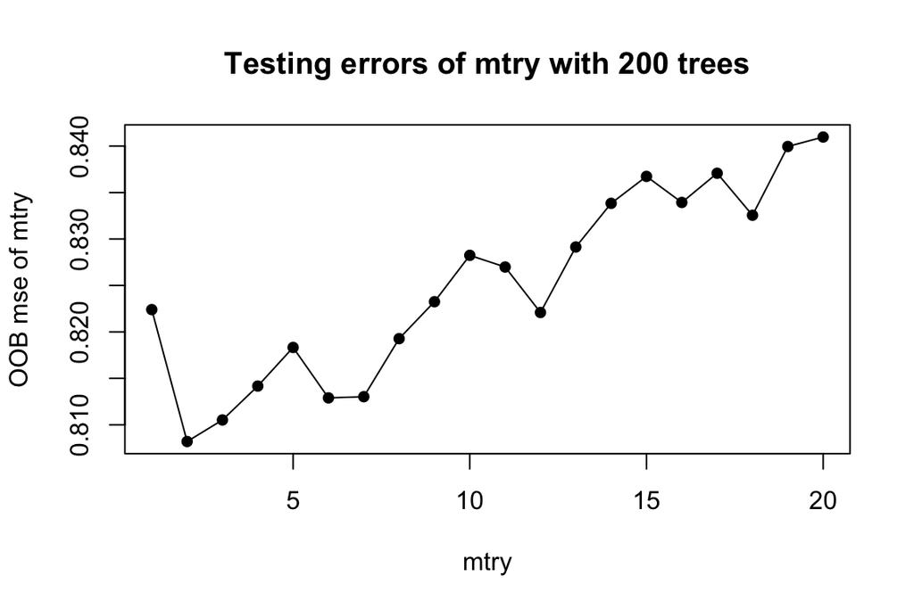

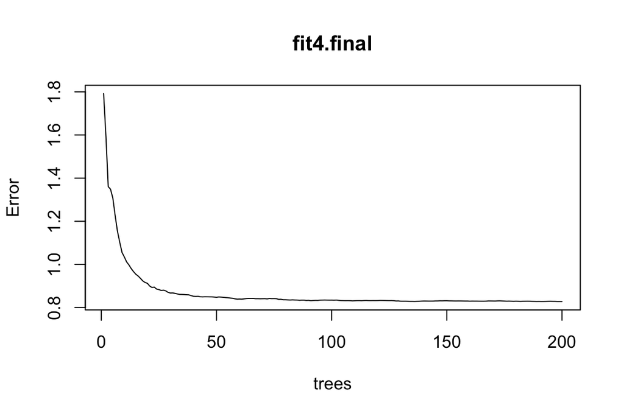

**Answer:**

```
## [1] 1.612985 1.577985 1.398297 1.402173 1.288155 1.213576
```

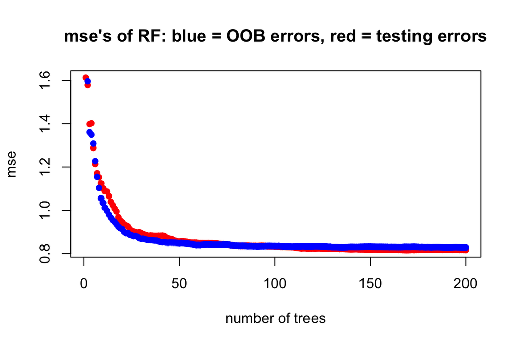

**Answer:** Overall, testing error using the test data is very similar to the error obtained using OOB. Thus, OOB errors estimate the testing error reasonably well.

```
c) What is the predicted value for Michelle?
```

[output not shown]

22. Now you have built so many predicted models (fit1 through fit4 in this section). What about build a fit5 which bags fit1 through fit4. Does fit5 have the smallest testing error?

```
## [1] "fit1 testing error:  0.669"
```

```
## [1] "fit2 testing error:  0.669"
```

```
## [1] "fit3 testing error:  1.064"
```

```
## [1] "fit4 testing error:  0.67"
```

```
## [1] "fit5 testing error:  1.046"
```

**Answer:** fit5 does not have the smallest testing error.

6. Summarize the results and nail down one best possible final model you will recommend to predict income. Explain briefly why this is the best choice. Finally for the first time evaluate the prediction error using the validating data set.

[output not shown]

```
## [1] "fit4 prediction error using the validation data set:  0.241"
```

7. Use your final model to predict Michelle’s income.

[output not shown]

# Problem 2: Yelp challenge 2019

**Note:** This problem is rather involved. It covers essentially all the main materials we have done so far in this semester. It could be thought as a guideline for your final project if you want when appropriate.

Yelp has made their data available to public and launched Yelp challenge. [More information](https://www.yelp.com/dataset/). It is unlikely we will win the $5,000 prize posted but we get to use their data for free. We have done a detailed analysis in our lecture. This exercise is designed for you to get hands on the whole process.

For this case study, we downloaded the [data](https://www.yelp.com/dataset/download) and took a 20k subset from **review.json**. *json* is another format for data. It is flexible and commonly-used for websites. Each item/subject/sample is contained in a brace *{}*. Data is stored as **key-value** pairs inside the brace. *Key* is the counterpart of column name in *csv* and *value* is the content/data. Both *key* and *value* are quoted. Each pair is separated by a comma. The following is an example of one item/subject/sample.

**Data needed:** yelp_review_20k.json available in Canvas.

**yelp_review_20k.json** contains full review text data including the user_id that wrote the review and the business_id the review is written for. Here’s an example of one review.

## Goal of the study

The goals are

1. Try to identify important words associated with positive ratings and negative ratings. Collectively we have a sentiment analysis.
2. To predict ratings using different methods.

## 1. JSON data and preprocessing data

1. Load *json* data

The *json* data provided is formatted as newline delimited JSON (ndjson). It is relatively new and useful for streaming.

The traditional JSON format is as follows.

We use `stream_in()` in the `jsonlite` package to load the JSON data (of ndjson format) as `data.frame`. (For the traditional JSON file, use `fromJSON()` function.)

```
## 'data.frame':    19999 obs. of  9 variables:
##  $ review_id  : chr  "Q1sbwvVQXV2734tPgoKj4Q" "GJXCdrto3ASJOqKeVWPi6Q" "2TzJjDVDEuAW6MR5Vuc1ug" "yi0R0Ugj_xUx_Nek0-_Qig" ...
##  $ user_id    : chr  "hG7b0MtEbXx5QzbzE6C_VA" "yXQM5uF2jS6es16SJzNHfg" "n6-Gk65cPZL6Uz8qRm3NYw" "dacAIZ6fTM6mqwW5uxkskg" ...
##  $ business_id: chr  "ujmEBvifdJM6h6RLv4wQIg" "NZnhc2sEQy3RmzKTZnqtwQ" "WTqjgwHlXbSFevF32_DJVw" "ikCg8xy5JIg_NGPx-MSIDA" ...
##  $ stars      : num  1 5 5 5 1 4 3 1 2 3 ...
##  $ useful     : int  6 0 3 0 7 0 5 3 1 1 ...
##  $ funny      : int  1 0 0 0 0 0 4 1 0 0 ...
##  $ cool       : int  0 0 0 0 0 0 5 1 0 1 ...
##  $ text       : chr  "Total bill for this horrible service? Over $8Gs. These crooks actually had the nerve to charge us $69 for 3 pil"| __truncated__ "I *adore* Travis at the Hard Rock's new Kelly Cardenas Salon!  I'm always a fan of a great blowout and no stran"| __truncated__ "I have to say tha…
##  $ date       : chr  "2013-05-07 04:34:36" "2017-01-14 21:30:33" "2016-11-09 20:09:03" "2018-01-09 20:56:38" ...
```

**Write a brief summary about the data:**

1. Which time period were the reviews collected in this data?

```
##   start.date   end.date
## 1 2004-10-19 2018-10-04
```

The reviews were written between Oct. 19th, 2004 and Oct. 4th, 2018.

2. Are ratings (with 5 levels) related to month of the year or days of the week? Only address this through EDA please.

```
## [1] "Proportion Table: Days of Week - Within a Day"
```

```
##    day.of.week
##         Friday     Monday   Saturday     Sunday   Thursday    Tuesday
##   1 0.15143084 0.14023313 0.15587604 0.14760026 0.14467103 0.15697036
##   2 0.07233704 0.07983045 0.07947223 0.07922419 0.06925741 0.07537505
##   3 0.09936407 0.11762628 0.09726910 0.12590401 0.11427472 0.11086718
##   4 0.21065183 0.22889438 0.20773243 0.22090730 0.21700654 0.21039151
##   5 0.46621622 0.43341575 0.45965020 0.42636423 0.45479030 0.44639590
##    day.of.week
##      Wednesday
##   1 0.12984432
##   2 0.07817158
##   3 0.11990725
##   4 0.22855250
##   5 0.44352435
```

```
## [1] "Proportion Table: Days of Week - Within a Star"
```

```
##    day.of.week
##        Friday    Monday  Saturday    Sunday  Thursday   Tuesday Wednesday
##   1 0.1299454 0.1354025 0.1732606 0.1531378 0.1282401 0.1463165 0.1336971
##   2 0.1189542 0.1477124 0.1692810 0.1575163 0.1176471 0.1346405 0.1542484
##   3 0.1113586 0.1483296 0.1412027 0.1706013 0.1322940 0.1349666 0.1612472
##   4 0.1216713 0.1487603 0.1554178 0.1542700 0.1294766 0.1320018 0.1584022
##   5 0.1312668 0.1373098 0.1676365 0.1451432 0.1322739 0.1365264 0.1498433
```

```
## [1] "Proportion Table: Month of Year - Within a Month"
```

```
##    month.of.year
##          April     August   December   February    January       July
##   1 0.13734393 0.15124046 0.17428571 0.13243243 0.13674762 0.15568544
##   2 0.07548241 0.08730916 0.07071429 0.08783784 0.06758184 0.07863974
##   3 0.12656073 0.10400763 0.10142857 0.11959459 0.12988384 0.10945802
##   4 0.21112372 0.22566794 0.22857143 0.21756757 0.24234424 0.20403826
##   5 0.44948922 0.43177481 0.42500000 0.44256757 0.42344245 0.45217853
##    month.of.year
##           June      March        May   November    October  September
##   1 0.15847348 0.14582098 0.14814815 0.12489927 0.14003486 0.15285714
##   2 0.07373868 0.07409603 0.07883598 0.08058018 0.06565950 0.07714286
##   3 0.09120310 0.11677534 0.11269841 0.13618050 0.10342824 0.09642857
##   4 0.18822768 0.21695317 0.22222222 0.21112006 0.24288205 0.19214286
##   5 0.48835705 0.44635448 0.43809524 0.44721998 0.44799535 0.48142857
```

```
## [1] "Proportion Table: Month of Year - Within a Star"
```

```
##    month.of.year
##          April     August   December   February    January       July
##   1 0.08253752 0.10811733 0.08321965 0.06684857 0.08833561 0.09993179
##   2 0.08692810 0.11960784 0.06470588 0.08496732 0.08366013 0.09673203
##   3 0.09933185 0.09710468 0.06325167 0.07884187 0.10957684 0.09175947
##   4 0.08539945 0.10858586 0.07346189 0.07392103 0.10537190 0.08815427
##   5 0.08863026 0.10127574 0.06658460 0.07329902 0.08974933 0.09523277
##    month.of.year
##           June      March        May   November    October  September
##   1 0.08356071 0.08390177 0.09549795 0.05286494 0.08219645 0.07298772
##   2 0.07450980 0.08169935 0.09738562 0.06535948 0.07385621 0.07058824
##   3 0.06280624 0.08775056 0.09487751 0.07527840 0.07928731 0.06013363
##   4 0.06680441 0.08402204 0.09641873 0.06014692 0.09595960 0.06175390
##   5 0.08448970 0.08426589 0.09265891 0.06210833 0.08628021 0.07542525
```

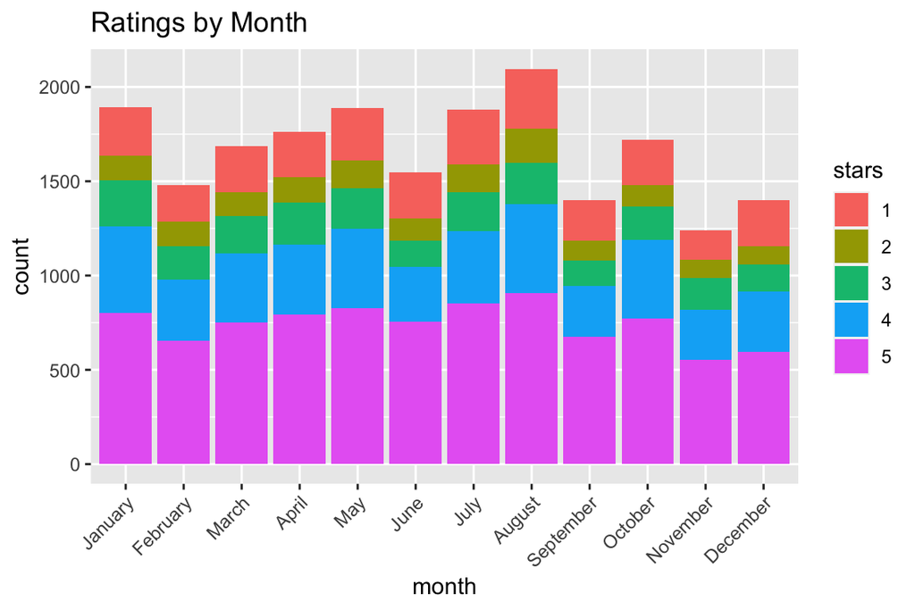

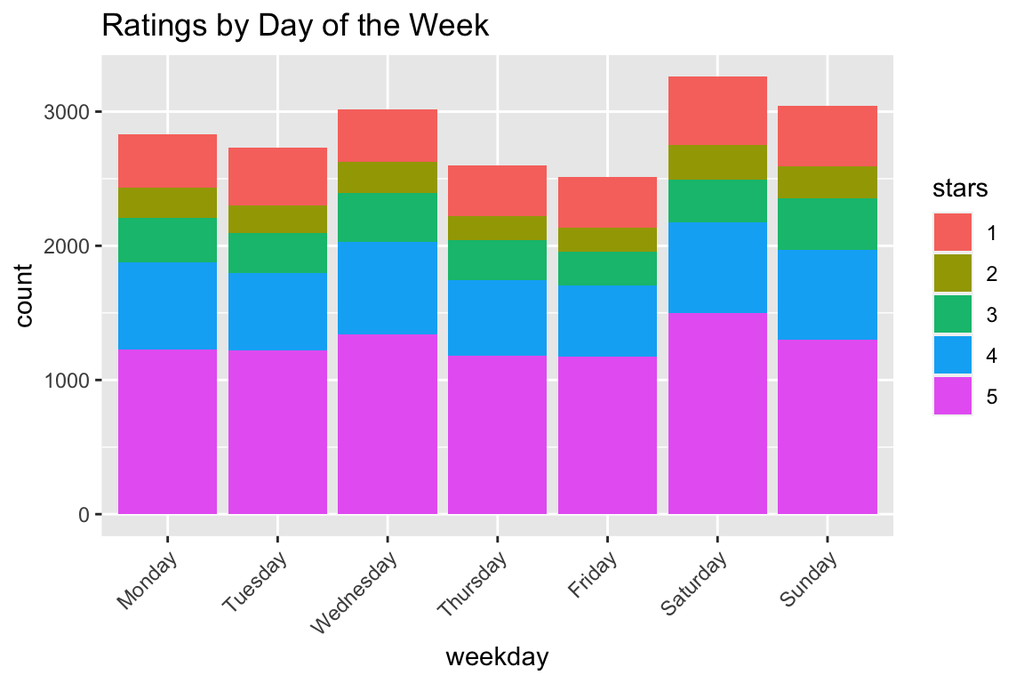

It appears based on the above proportion tables that there is no major relationship between day of the week or month of the year and review score.

2. Document term matrix (dtm)

Extract document term matrix for texts to keep words appearing at least .5% of the time among all 20000 documents. Go through the similar process of cleansing as we did in the lecture.

```
## <<DocumentTermMatrix (documents: 19999, terms: 1337)>>
## Non-/sparse entries: 713107/26025556
## Sparsity           : 97%
## Maximal term length: 13
## Weighting          : term frequency (tf)
## Sample             :
##        Terms
## Docs    food get good great just like order place servic time
##   10892    3   0    3     3    3    3     2     0      0    0
##   12262    2   4    0     0    2    4     4     1      2    3
##   16453    2   2    4     2    7    6     7     5      0    5
##   1755     0  10    0     0    0    2     1     1      4    7
##   3109     3   0    0     0    4    1     4     2      0    3
##   3563     0   3    1     0    4    2     0     0      0    5
##   5749     1   6    3     1    2    2     1     0      1    6
##   5917     0   5    0     0    0    1     0     4      4    5
##   8357     1   2    4     1    4    2     4     1      2    3
##   9106     8   5    3     1    3    2     3     1      3    3
```

1. Briefly explain what does this matrix record? What is the cell number at row 100 and column 405? What does it represent?

This matrix records the amount of times that a particular word appears in a given review.

```
## <<DocumentTermMatrix (documents: 1, terms: 1)>>
## Non-/sparse entries: 0/1
## Sparsity           : 100%
## Maximal term length: 6
## Weighting          : term frequency (tf)
## Sample             :
##      Terms
## Docs  except
##   100      0
```

At row 100, column 405, we have a number 0. This corresponds to the amount of times that a particular word (the word in column 405) appears in document 100.

2. What is the sparsity of the dtm obtained here? What does that mean?

The sparsity of the matrix is 97% here, meaning that 97% of the elements are zero. This means that 97% of the time a given word does not appear in a given document.

3. Set the stars as a two category response variable called rating to be “1” = 5,4 and “0”= 1,2,3. Combine the variable rating with the dtm as a data frame called data2.

```
##    rating abl absolut accept accommod acknowledg across act actual add addit
## 1       0   0       0      0        0          0      0   0      1   0     0
## 2       1   0       0      0        0          0      0   0      0   0     0
## 3       1   0       0      0        0          0      0   0      0   0     0
## 4       1   0       1      0        1          0      1   0      0   0     0
## 5       0   0       0      0        0          1      0   0      0   0     0
## 6       1   0       0      0        0          0      0   0      0   0     0
## 7       0   0       0      0        0          0      0   0      0   1     0
## 8       0   0       0      0        0          0      0   0      0   0     0
## 9       0   2       0      0        0          0      0   0      0   0     0
## 10      0   0       0      0        0          0      0   0      0   0     0
##    address admit adult advanc advertis advic afford afternoon age ago agre
## 1        0     0     0      0        0     0      0         0   0   0    0
## 2        0     0     0      0        0     0      0         0   0   0    0
## 3        0     0     0      0        0     0      0         0   0   0    0
```

[output cut: 18 more lines]

## Analysis

Get a training data with 13000 reviews and the 5000 reserved as the testing data. Keep the rest (2000) as our validation data set.

## 2. LASSO

1. Use the training data to get Lasso fit. Choose lambda.1se. Keep the result here.

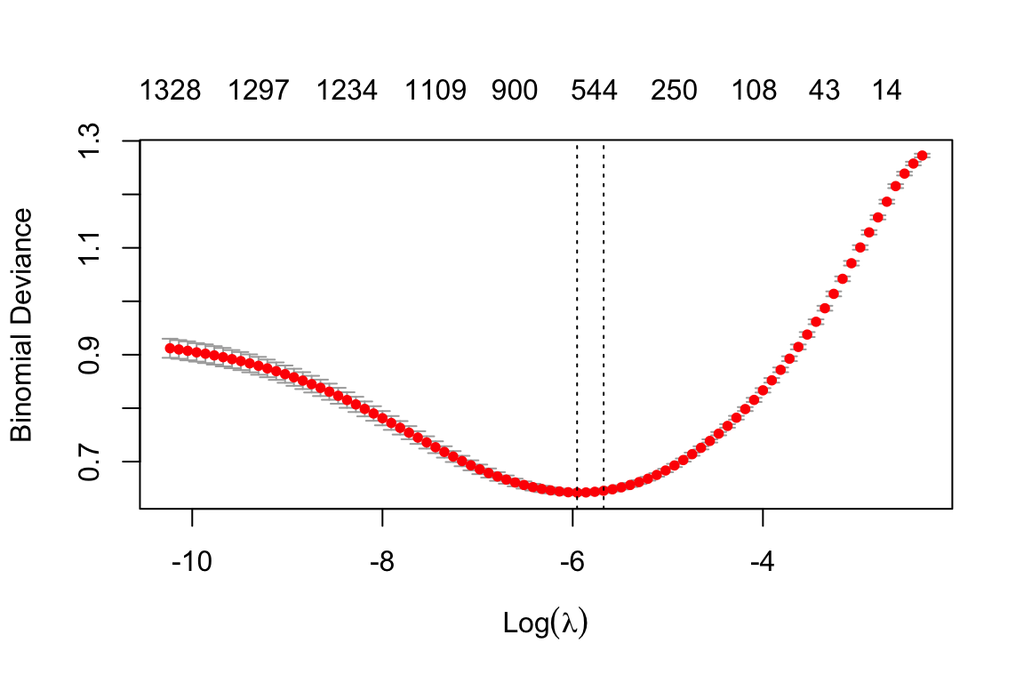

2. Feed the output from Lasso above, get a logistic regression.
1. Pull out all the positive coefficients and the corresponding words. Rank the coefficients in a decreasing order. Report the leading 2 words and the coefficients. Describe briefly the interpretation for those two coefficients.

```
## thorough  delight
##   2.4116   1.9200
```

Among all the words used in the sampled reviews, “thorough” and “delight” are most predictive of a high rating. For each time that “thorough” or “delight” are used in a review, the log(odds) of the rating being 4 or 5 stars increases by about 2.4116 and 1.92, respectively.

2. Make a word cloud with the top 100 positive words according to their coefficients. Interpret the cloud briefly.

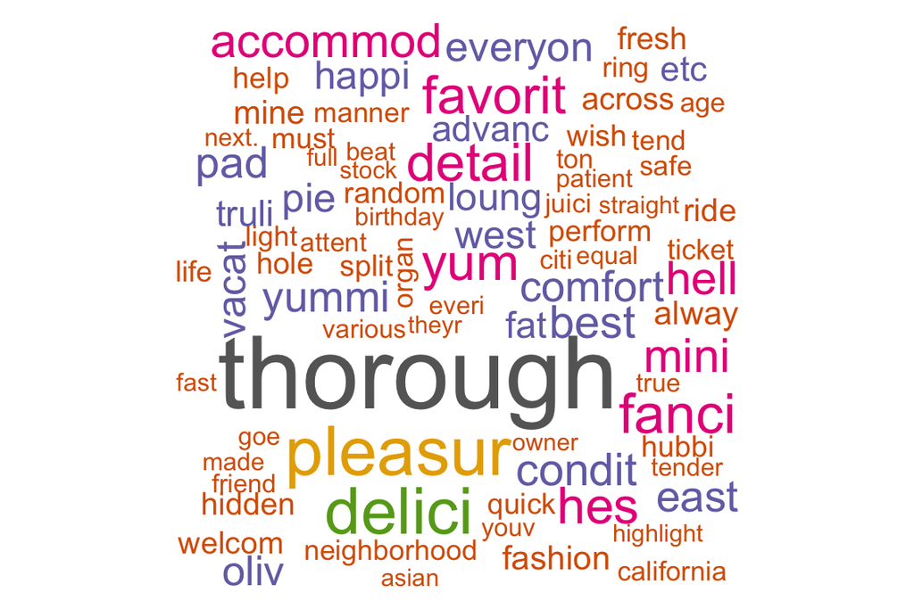

3. Repeat i) and ii) for the bag of negative words.

```
##   wors   rude
## 2.3556 2.1109
```

Out of all words stems to appear in the reviews, “wors” and “rude” are most predictive of a low (3 or fewer star) rating. For each time that “wors” or “rude” are used in a review, the log(odds) of the rating being 4 or 5 stars decreases by about 2.3556 and 2.1109, respectively.

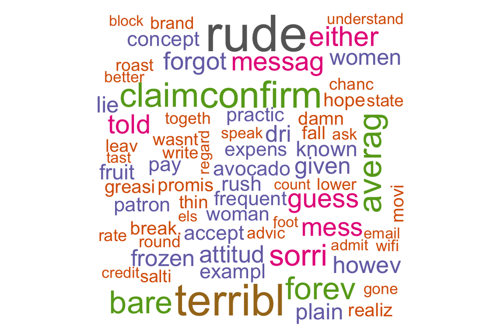

4. Summarize the findings.
3. Using majority votes find the testing errors i) From Lasso fit in 3)

```
ii) From logistic regression in 4)


iii) Which one is smaller?
```

The testing error for the LASSO fit (0.1342) is smaller than that of the logistic regression (0.2004).

## 3. Random Forest

1. Briefly summarize the method of Random Forest

Random Forest methods consist of leveraging multiple decision trees to solve classification or regression problems. Each tree is built recursively as a series of split-points, each optimized from among a set of variables to minimize misclassification error (for classification) or residual sum of squares (for regression). In Random Forest, some number of such decision trees are initialized, each using a subset of the available variables, and a bootstrapped sampled of the data. In the case of a regression problem, the aggregated output is typically an average of all predictions based on each decision tree. In the case of a classification problem, the aggregated output is typically a majority vote, based on the classification by each decision tree.

2. Now train the data using the training data set by RF. Get the testing error of majority vote. Also explain how you tune the tuning parameters (`mtry` and `ntree`).

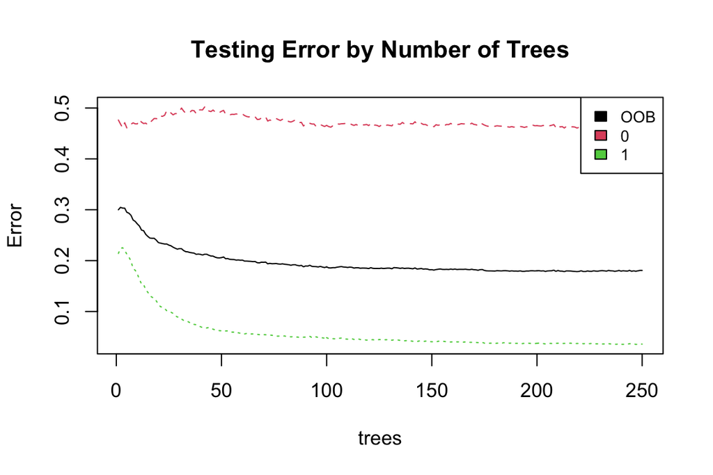

In order to tune the ntree parameter, we have plotted the Out of Bag classification error against the number of trees used, with mtry held constant. Based on this plot, 100-150 trees seem to be appropriate, as the decrease in error is negligible past this point. Accordingly, we opted to use 150 trees.

Now, we will focus on optimizing mtry. To do this, we will do randomForest over a range of mtry values, with ntree held constant, and plot the OOB classification error for each value. Because this process will be computationally expensive, I have run my code with parallel processing and saved the output to mse_mtry.Rdata, so as to not have to re-run this chunk.

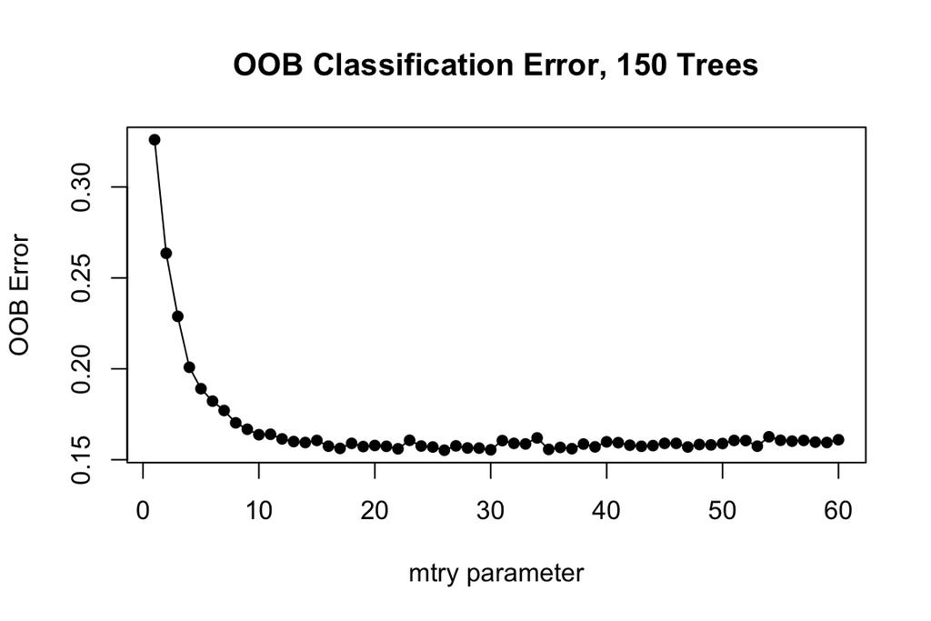

As we can see, the OOB classification error begins to plateau around 20 variables, so we can select this as our mtry.

```
##   OOB
## 0.162
```

The testing error of majority vote is: 0.1484.

## 4. Boosting - REMOVED

SECTION REMOVED

## 5. PCA first

1. Perform PCA (better to do sparse PCA) for the input matrix first. Decide how many PC’s you may want to take and why.

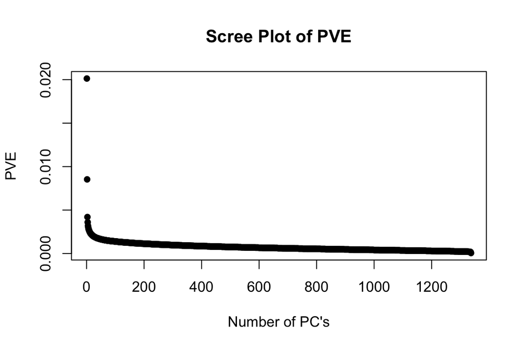

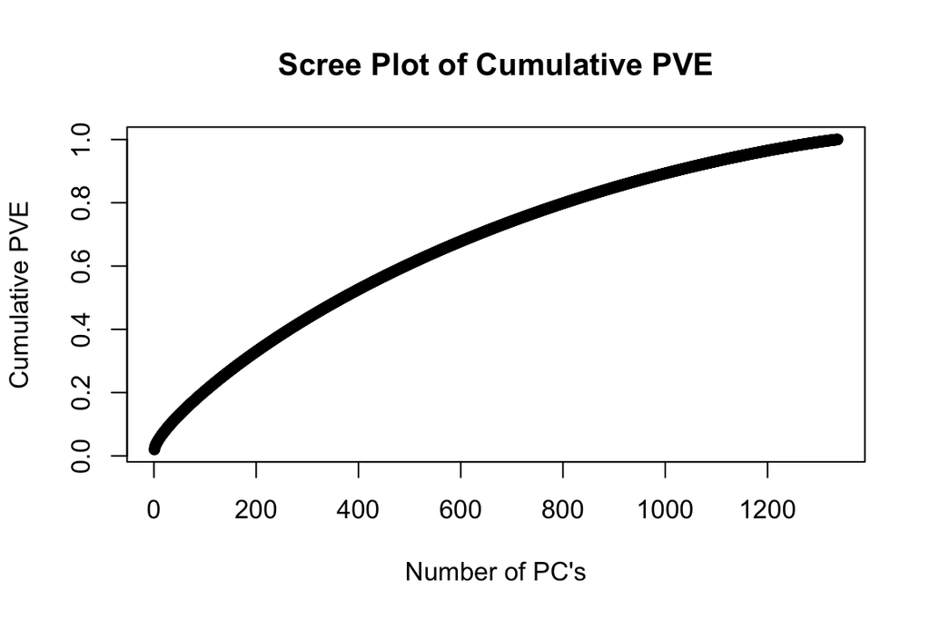

Using 100 PCs based on where PVE levels off in our scree plot.

2. Pick up one of your favorite method above and build the predictive model with PC’s.

Using relaxed LASSO since it had a smaller testing error on the original data.

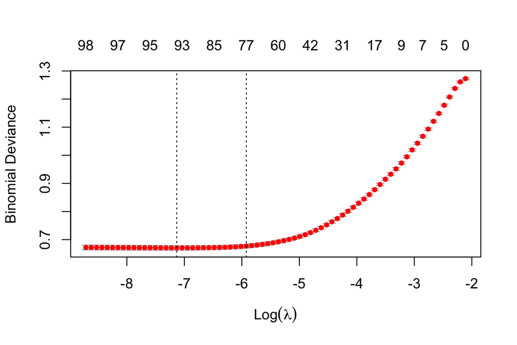

3. What is the testing error? Is this testing error better than that obtained using the original x’s?

The testing error of the LASSO fit modeled using the 100 leading PCs is 0.1362, almost identical for the testing error of the LASSO fit on the original data (0.1342).

## 6. Ensemble model

1. Take average of some of the models built above (also try all of them) and this gives us the fifth model. Report it’s testing error. (Do you have more models to be bagged, try it.)

```
## [1] 0.3414
```

We created several ensemble models based on the Random Forest, LASSO, logistic regression, and PCA+LASSO models fitted above. First we classified reviews based on majority vote of the classifications assigned by each individual model (i.e. the mode of the predictions, similar to the approach used by RandomForest). This resulted in a prediction error of 0.3414; far worse than our best fitting model (LASSO). Next, we used each model to calculate the probability of a rating being 4 or above, averaged the probabilities across models, and used this average to classify based on a majority vote (threshold at probability >0.5). This improved our testing error to 0.1314. Finally, we ran the same calculation but without including the probability predicted by our lowest-performing model (logistic regression, testing error = 0.2004), resulting in a testing error of 0.1254 for our final ensemble model.

## 7. Final model

Which classifier(s) seem to produce the least testing error? Are you surprised? Report the final model and accompany the validation error. Once again this is THE only time you use the validation data set. For the purpose of prediction, comment on how would you predict a rating if you are given a review (not a tm output) using our final model?

```
##           model test.err
## 7 EnProbReduced   0.1254
```

Our Final Model: Average Probability Ensemble of LASSO, RandomForest, and PCA+LASSO

The model that produces the lowest testing error is the final ensemble model (majority vote classification based on probabilities averaged from LASSO, RandomForest, and PCA+LASSO). This is not terribly surprising, as the ensemble approach is able to minimize variance by averaging probabilities from our highest-performing models. However, this approach lacks interpretability and only slightly improves testing error beyond that of our LASSO model.

The validation error for our final model is 0.1205603.

Were we tasked with making a prediction with this model, given a review, we would extract a dtm and then apply our classification model much as we did with the validation dataset. Specifically, we would:

1. Process the text. This involves cleaning procedures such as removing punctuation, stem words, etc.
2. Generate word counts for each word that appears in the review as a data.frame.
3. Order the words as appears in the data.frame we used to train our model.
4. Convert this data frame to a 1D matrix.
5. Predict probability of a positive rating on our LASSO model by feeding the dtm as input to the predict() function, using our fit.lasso as the model, with type=‘response’, s=‘lambda.1se’.
6. Predict probability of a positive rating on our Random Forest model by feeding the dtm as input to the predict() function, using our rf.fit.final as the model, with type=‘prob’.
7. Predict probability of a positive rating on our PCA+LASSO model by applying our PC loadings to the dtm using predict() and then feeding the first 100 PCs to the predict() function, using our fit.lasso as the model, with type=‘response’, s=‘lambda.1se’.
8. Average the predicted probabilities from steps 5-7 and classify the review based on majority vote (e.g. assign a “good” rating of 4-5 stars if probability >0.5, else assign a “bad” rating of 1-3 stars)